# Bootstrap for testing block model of SBM.

Zeinab Mousavi

Bootstrap implementation for evaluating goodness of fit of two SBM models.

### Description

Input $A$ is a SBM graph. We compare its goodness of fit under the null and alternative models, where the number of blocks are 2 and 3 respectively:

$A$ is defined by $\theta(\tau, B, k)$ , where $A_{i,j}$ ~ $Bern(B_{i,j})$

$\tau_{i}$ is vector indicating group index of vertex i ($\tau$ is nx1 vector)

k is number of blocks/groups in the graph

The likelihood is: $l = \displaystyle\prod_{i,j}^{n} B_{i,j}^{A_{i,j}}*{(1-B_{i,j})}^{(1-A_{i,j})}$

And log-likelihood: $loglik = \displaystyle\sum_{i,j}^{n} (A_{i,j}*log(B_{i,j})+(1-A_{i,j})*log(1-B_{i,j}))$

Evaluate parameter estimates of observed data under both models

fit $(A_{data}, k_{null})$ via k-means :: $\hat{A_{null}} = \theta(\hat{\tau_{null}}, \hat{B_{null}}, \hat{k_{null}})$

fit $(A_{data}, k_{alt})$ via k-means :: $\hat{A_{alt}} = \theta(\hat{\tau_{alt}}, \hat{B_{alt}}, \hat{k_{alt}})$

Compute test statistic of observed data

$\delta_{data} = -2 * (loglik(\hat{A_{null}}) - loglik(\hat{A_{alt}}))$

##### GLRT Test

for b in (1, .., B):

Simulate under null hypothesis:

$A^{b}$ ~ $\theta(\hat{\tau_{null}}, \hat{B_{null}}, k=k_{null})$

Fit to both models:

$A_{null}^{b}$ ~ fit $(A^{b}, k_{null})$ via k-means

$A_{alt}^{b}$ ~ fit $(A^{b}, k_{alt})$ via k-means

$\hat\delta^{b} = -2 * (loglik(A_{null}^{b}) - loglik(A_{alt}^{b}))$

end

p-value = $\frac{count(\hat\delta^{b} \geq \hat\delta_{obs})}{B}$

$\hat\delta_{c}$ = quantile $( \hat\delta^{b}, .95)$

##### Power of Test

Construct bootstrap samples under the alternative model

for b = {1, .., B}:

Simulate under alternative hypothesis:

$A^{b}$ ~ $\theta(\hat{\tau_{alt}}, \hat{B_{alt}}, k=k_{alt})$

Fit to both models:

$A_{null}^{b}$ ~ fit $(A^{b}, k_{null})$ via k-means

$A_{alt}^{b}$ ~ fit $(A^{b}, k_{alt})$ via k-means

$\hat\delta^{b} = -2 * (loglik(A_{null}^{b}) - loglik(A_{alt}^{b}))$

Power = $\frac{count(\hat\delta^{b} \geq \hat\delta_{c})}{B}$

# SBM 2 blocks vs 3 blocks

```r
require(igraph)
require(raster)
####################################
##FUNCTIONS#########################
####################################
sbm.sim <- function(A, k){

  A_kmeans <- kmeans(A[, 1:n], k, nstart = 20)

  log.b = c()
  B.fit = matrix( , nrow = k, ncol = k)
  for (i in seq(1, k, 1)){
    for (j in seq(1, k, 1)){
      if (i<=j){#SBM is symmetric, reduce computation
        B.fit[i, j] = mean(A[(A_kmeans$cluster==i), (A_kmeans$cluster==j)])
      }
      else {
        B.fit[i,j] = B.fit[j, i]
      }
    }
  }

  block.sizes.fit = A_kmeans$size
  list(block.sizes.est = block.sizes.fit, B.est =B.fit)
}


sbm.loglik = function(A, k){
  A_kmeans <- kmeans(A[, 1:n], k, nstart = 20)

  log.b = c()

  for (i in seq(1, k, 1)){
    for (j in seq(1, k, 1)){
      if (i<=j){#SBM is symmetric, reduce computation
        b_ij = mean(A[(A_kmeans$cluster==i), (A_kmeans$cluster==j)])
        log.b_ij = sum(A[(A_kmeans$cluster==i), (A_kmeans$cluster==j)])*log(b_ij) + (A_kmeans$size[i]*A_kmeans$size[j]-sum(A[(A_kmeans$cluster==i), (A_kmeans$cluster==j)]))*log(1-b_ij)
        if (i!=j){ #take advantage of SBM symmetry
          log.b_ij = 2*log.b_ij
        }
        log.b = sum(log.b, log.b_ij)
      }
    }
  }

  return(log.b)
}
```

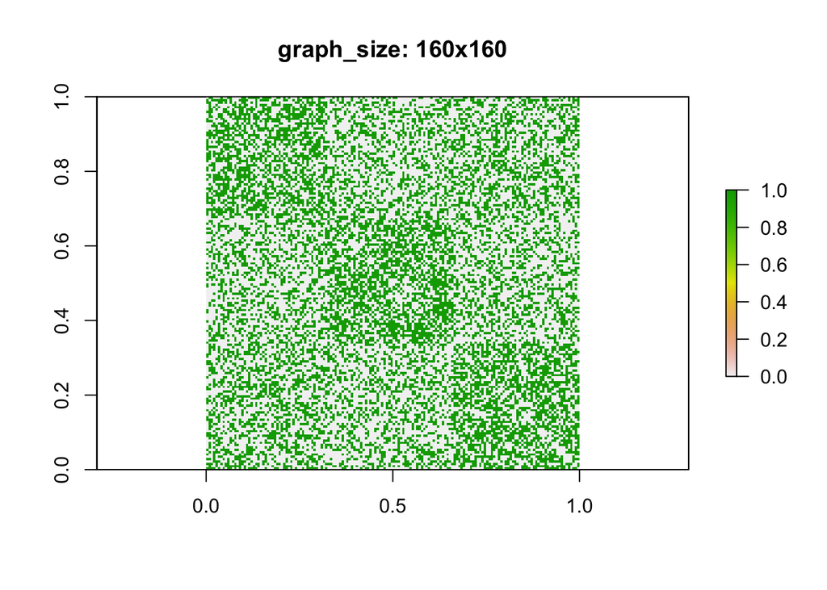

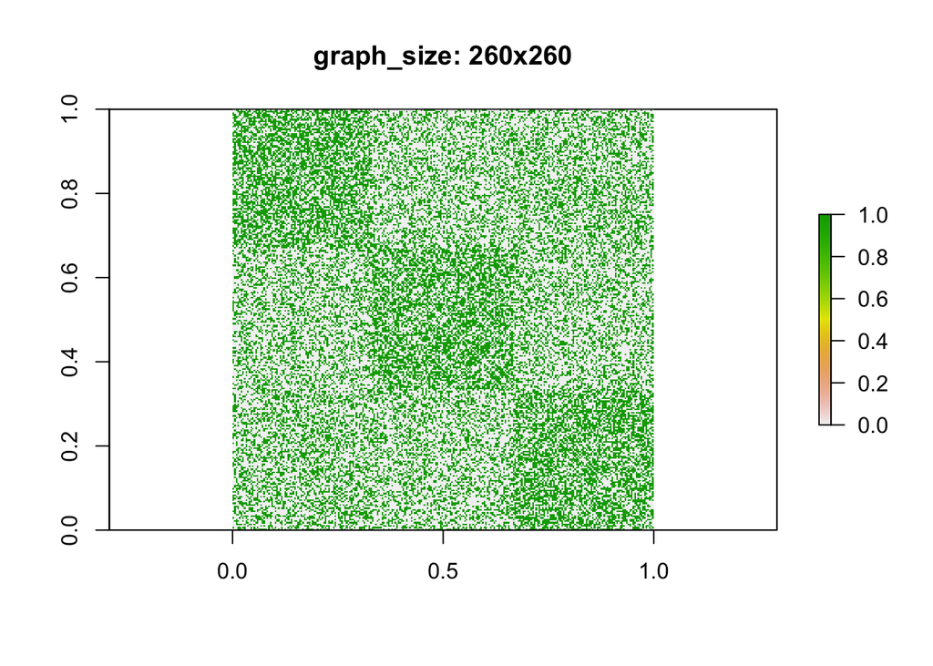

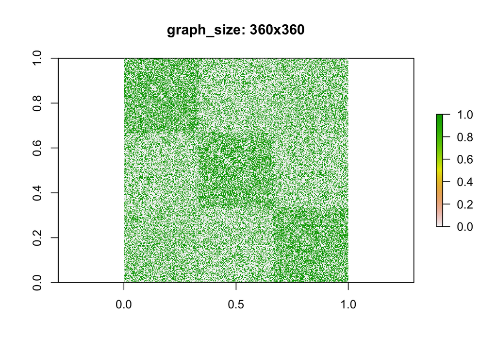

```r
k_null =2
k_alt = 3
graph_size = seq(160, 400, 20)
#graph_size = c(280)


p_value <- c()
power = c()
ctr = 0
for (n in graph_size){
m = ceiling(n/3)
###DATA


#3block
p<-0.55
q<-0.35
r<-0.4
block_sizes = c((n-2*m), m, m)
pm <- cbind( c(p, q, r), c(q, p, q) , c(r, q, p))


g.data <- sbm.game(sum(block_sizes), pref.matrix=pm, block.sizes=block_sizes, directed=FALSE,loops=FALSE)
A.data = as.matrix(get.adjacency(g.data))
if (ctr %% 5 ==0){
  title = paste("graph_size: ", as.character(n), "x", as.character(n), sep="")
  plot(raster(A.data), main=title)
}
#####

A.param.null <- sbm.sim(A.data,k_null)
A.param.alt <- sbm.sim(A.data,k_alt)

data.loglik.null <- sbm.loglik(A.data, 2)
data.loglik.alt <- sbm.loglik(A.data, 3)
data.stat = - 2 * (data.loglik.null - data.loglik.alt)


boot_strap <- 100
test.stat.null <- c()
test.stat.alt <- c()


for (b in seq(1, boot_strap)){

A.boot.null.sim <- sbm.game(sum(A.param.null$block.sizes.est), pref.matrix=A.param.null$B.est, block.sizes=A.param.null$block.sizes.est, directed=FALSE,loops=FALSE)
A.boot.null <- as.matrix(get.adjacency(A.boot.null.sim))

loglik.null <- sbm.loglik(A.boot.null, k_null)
loglik.alt <- sbm.loglik(A.boot.null, k_alt)
test.stat.null[b] = - 2 * (loglik.null - loglik.alt)
}

ctr = ctr+1
p_value[ctr] = sum(data.stat<test.stat.null)/boot_strap #== 1-ecdf(test.stat.null)(data.stat)
critical.stat = quantile(test.stat.null, 0.95)[1]

for (b in seq(1, boot_strap)){
  A.boot.alt.sim <- sbm.game(sum(A.param.alt$block.sizes.est), pref.matrix=A.param.alt$B.est, block.sizes=A.param.alt$block.sizes.est, directed=FALSE,loops=FALSE)
  A.boot.alt <- as.matrix(get.adjacency(A.boot.alt.sim))

  loglik.null <- sbm.loglik(A.boot.alt, k_null)
  loglik.alt <- sbm.loglik(A.boot.alt, k_alt)
  test.stat.alt[b] = - 2 * (loglik.null - loglik.alt)
}

power[ctr]= sum(critical.stat<test.stat.alt)/boot_strap

}
```

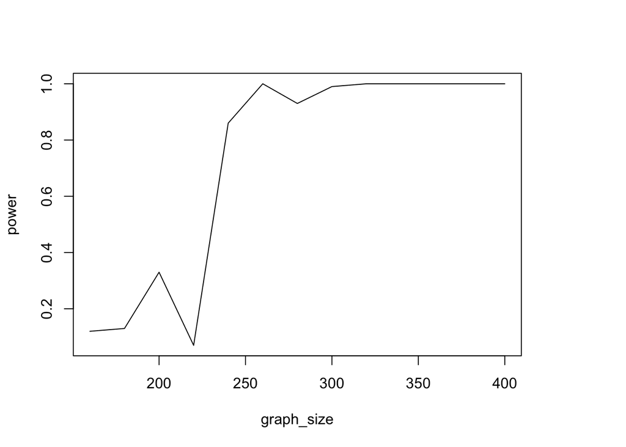

```r
plot(graph_size, power, type="l")
```